# `ciftiTools` Demo

### Applying a parcellation to data

`apply_parc` will apply a function to one `"xifti"` across each parcel specified by another `"xifti"`. A common example is computing the average timeseries of each parcel:

```r
parc <- load_parc("Yeo_7")
parc_tab <- parc$meta$cifti$labels[[1]]
rbind(head(parc_tab), tail(parc_tab)) # Keys 0-51 (52 total)
```

```
##                               Key      Red     Green      Blue Alpha
## ???                             0 1.000000 1.0000000 1.0000000     0
## 7Networks_LH_Vis                1 0.470588 0.0705882 0.5254900     1
## 7Networks_LH_SomMot             2 0.274510 0.5098040 0.7058820     1
## 7Networks_LH_DorsAttn_Post      3 0.000000 0.4627450 0.0549020     1
## 7Networks_LH_DorsAttn_FEF       4 0.000000 0.4627450 0.0588235     1
## 7Networks_LH_DorsAttn_PrCv      5 0.000000 0.4666670 0.0549020     1
## 7Networks_RH_Cont_PFCmp        46 0.901961 0.5803920 0.1411760     1
## 7Networks_RH_Default_Par       47 0.803922 0.2431370 0.3019610     1
## 7Networks_RH_Default_Temp      48 0.803922 0.2392160 0.3058820     1
## 7Networks_RH_Default_PFCv      49 0.803922 0.2392160 0.3019610     1
## 7Networks_RH_Default_PFCdPFCm  50 0.800000 0.2431370 0.3058820     1
## 7Networks_RH_Default_pCunPCC   51 0.800000 0.2431370 0.3019610     1
```

```r
dat <- read_cifti(ciftiTools.files()$cifti["dtseries"])
dim(dat)
```

```
## [1] 60951     2
```

```r
pmean <- apply_parc(
  dat, parc,
  FUN=colMeans, # get average timeseries
  na.rm=TRUE # medial wall vals in `dat` will be NA
)
dim(pmean) # 52 parcels x 2 data columns
```

```
## [1] 52  2
```

For real timeseries data, `cor(t(pmean))` would give the parcels x parcels functional connectivity matrix.

`apply_parc` also has an argument which converts the result to a `"xifti"` object. Each locations’ value will be the value of its corresponding parcel.

```r
# Obtain the min/max, quartile, and mean value
#   of the second data column, within each parcel.
psumm <- apply_parc(
  select_xifti(dat, idx=2),
  parc, mwall_value=0,
  FUN=summary,
  return_as="xifti"
)

# Plot the median.
plot(psumm, idx=3, title=psumm$meta$cifti$names[3], colors="magma")
```

```
## `zlim` not provided: using color range 0 - 3.2 (data limits: 0 - 3.41).
```

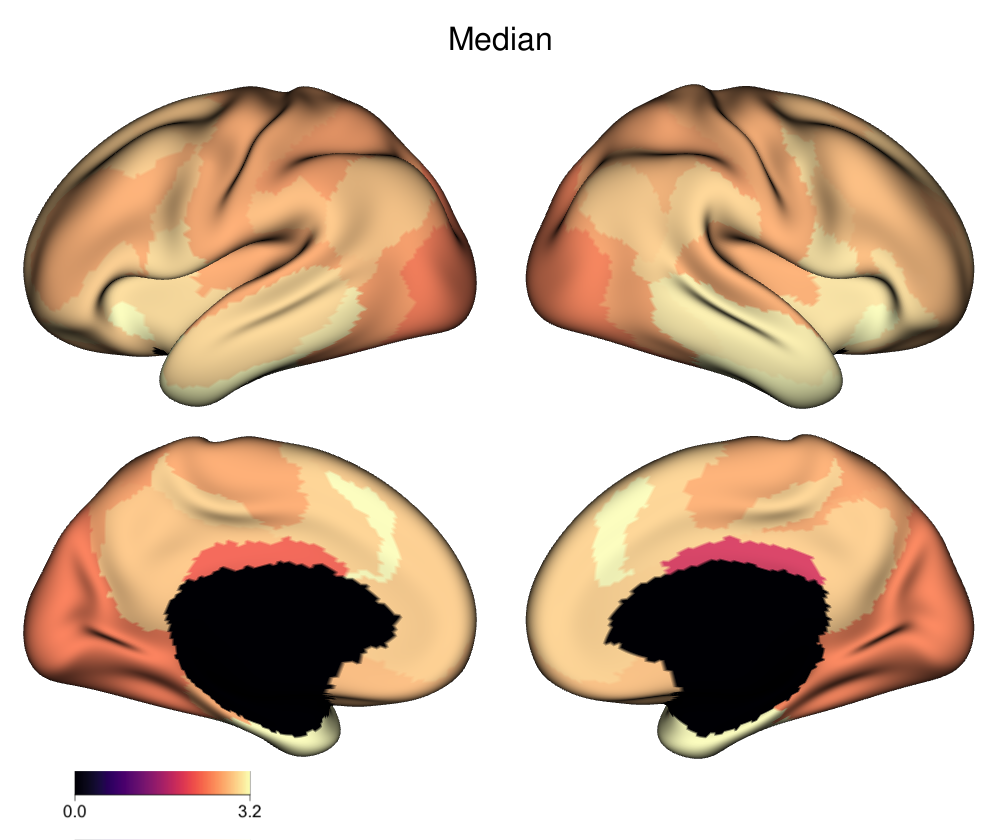

Median parcel value

```r
if (is_knit) { knit_pic() }
```

# Citing `ciftiTools`

A citation for the package itself can be printed with:

```r
citation("ciftiTools")
```

```
##
##   Pham DD, Muschelli J, Mejia AF (2021). "ciftiTools: A package for
##   reading, writing, visualizing and manipulating CIFTI files in R."
##   _NeuroImage_, *250*. doi:10.1016/j.neuroimage.2022.118877
##   <https://doi.org/10.1016/j.neuroimage.2022.118877>.
##
## A BibTeX entry for LaTeX users is
##
##   @Article{,
##     title = {{ciftiTools}: A package for reading, writing, visualizing and manipulating {CIFTI} files in {R}},
##     author = {Damon D Pham and John Muschelli and Amanda F Mejia},
##     year = {2021},
##     journal = {NeuroImage},
##     volume = {250},
##     doi = {10.1016/j.neuroimage.2022.118877},
##   }
```

Refer to the README for citation information for the surfaces, parcellations, and other data included in `ciftiTools`, as well as the Connectome Workbench. Also check the DESCRIPTION file to get a list of R packages used, including `rgl` and `papayar`.